# Network measures and plots in R

# 1 **Prepare for the fight**

getwd() —check the working directory  
setwd() —if necessary  
dir() —check out the files  
required packages  
library(igraph)

# 2 **Network basics –reminder**

“clusternetwork2012.csv” is the adjacency matrix of a knowledge sharing network in an industry cluster. Nodes are firms, edges represent asking for technical advice.

```r
# network from adjacency matrix
Knet <- graph.adjacency(as.matrix(read.csv("clusternetwork2012.csv", sep = ";",
                                           header = TRUE, row.names = 1)))
Knet
```

```
## IGRAPH 7d4a874 DN-- 26 223 --
## + attr: name (v/c)
## + edges from 7d4a874 (vertex names):
##  [1] P1 ->P9  P1 ->P10 P1 ->P11 P1 ->P16 P1 ->P17 P1 ->P18 P1 ->P21
##  [8] P1 ->P22 P1 ->P30 P2 ->P8  P2 ->P15 P2 ->P17 P2 ->P20 P2 ->P22
## [15] P2 ->P26 P3 ->P4  P3 ->P17 P3 ->P19 P3 ->P20 P3 ->P23 P3 ->P24
## [22] P4 ->P13 P4 ->P17 P4 ->P20 P4 ->P21 P5 ->P4  P5 ->P9  P5 ->P11
## [29] P5 ->P15 P5 ->P18 P5 ->P21 P6 ->P4  P6 ->P5  P6 ->P8  P6 ->P9
## [36] P6 ->P11 P6 ->P12 P6 ->P17 P6 ->P18 P6 ->P21 P6 ->P22 P6 ->P24
## [43] P7 ->P13 P8 ->P11 P9 ->P5  P9 ->P11 P9 ->P15 P9 ->P17 P9 ->P18
## [50] P9 ->P26 P10->P11 P10->P17 P10->P21 P10->P23 P10->P26 P10->P30
## + ... omitted several edges
```

Quick check on degree distribution

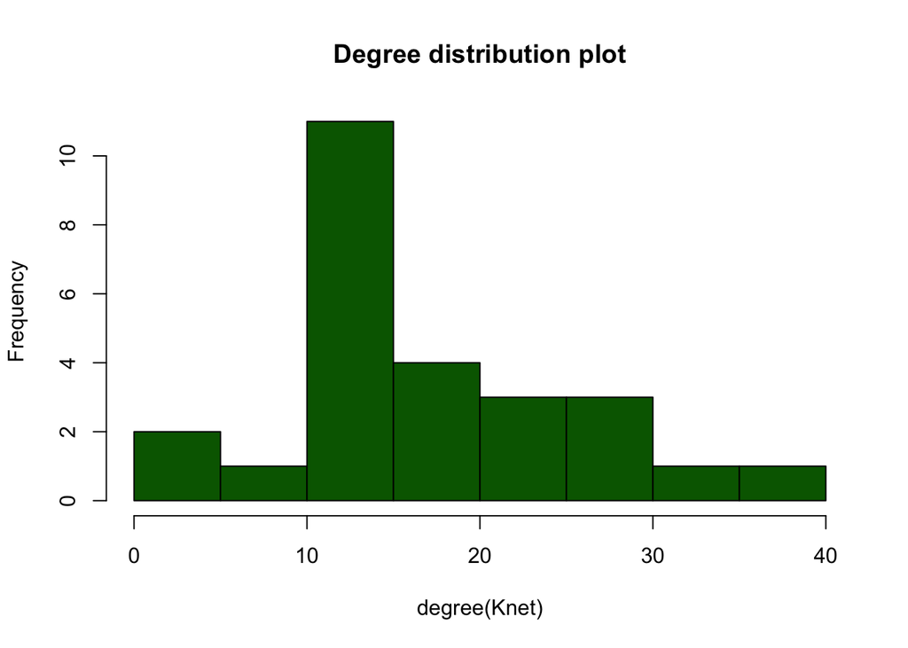

```r
# degree distr plot
hist(degree(Knet), col = "darkgreen", main = "Degree distribution plot")
```

Plot the network

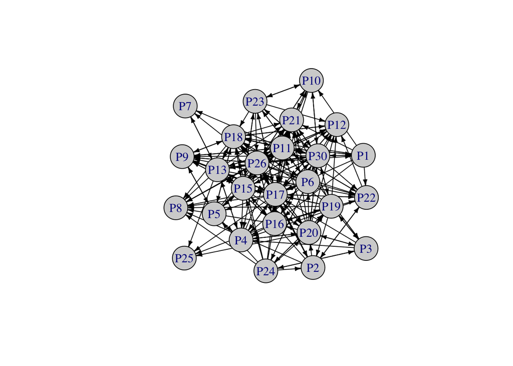

```r
set.seed(10) # for reproduction
layout1 <- layout_with_graphopt(Knet, niter=800, charge=0.2)# set up the layout

plot(Knet, layout=layout1,
     vertex.color="lightgray", edge.color="black",
     vertex.size=25, edge.arrow.size=0.4)
```

Construct a dataframe for node indicators

```r
df <- data.frame(V(Knet)$name, degree(Knet))
colnames(df) <- c("firm_id", "degree")
head(df)
```

|  | firm_id | degree |
| --- | --- | --- |
| P1 | P1 | 12 |
| P2 | P2 | 11 |
| P3 | P3 | 10 |
| P4 | P4 | 14 |
| P5 | P5 | 11 |
| P6 | P6 | 17 |

# 3 **Network measures**

Calculate a few basic network measures and check for correlations

1. local clustering

```r
# lc - local clustering
lc <- transitivity(Knet, type="local")
lc
```

```
##  [1] 0.4848485 0.3454545 0.2000000 0.3626374 0.3636364 0.4044118 0.5000000
##  [8] 0.5090909 0.2571429 0.3272727 0.1847291 0.3904762 0.1976285 0.2338462
## [15] 0.2549020 0.1801802 0.2400000 0.3333333 0.2761905 0.5416667 0.3333333
## [22] 0.2435897 0.4358974 0.8333333 0.2086022 0.2010582
```

2. brokerage

```r
# brokerage based on Burt's constraint measure
brokerage <- constraint(Knet)
brokerage
```

```
##        P1        P2        P3        P4        P5        P6        P7
## 0.2457402 0.2356001 0.2822209 0.2073183 0.2560348 0.2023608 0.4768874
##        P8        P9       P10       P11       P12       P13       P15
## 0.2113500 0.2503627 0.2795187 0.1846781 0.2263966 0.1947030 0.1849786
##       P16       P17       P18       P19       P20       P21       P22
## 0.2105769 0.1650281 0.1948308 0.2079876 0.1883871 0.1946837 0.2225496
##       P23       P24       P25       P26       P30
## 0.2353624 0.2152239 0.3546452 0.1781866 0.1864156
```

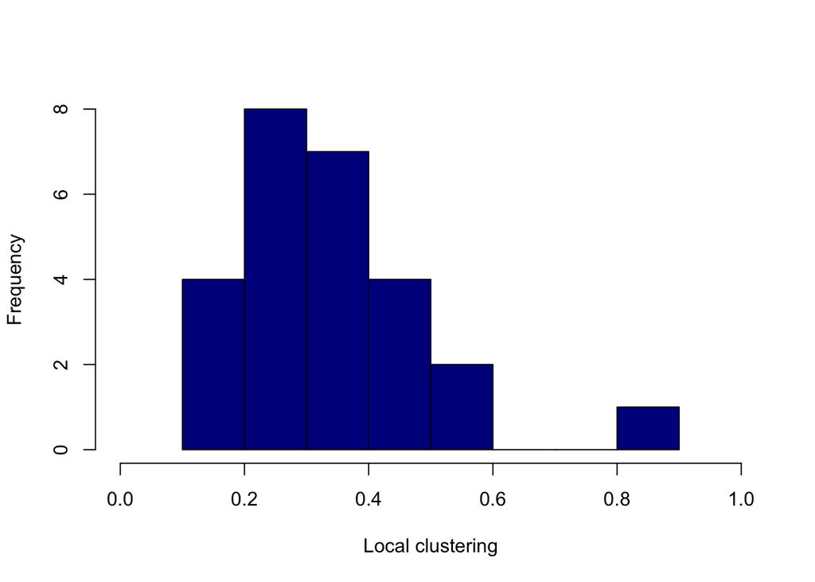

```r
# check the distribution of constraint based brokerage
hist(lc, col="darkblue", main='', xlab='Local clustering', xlim=c(0,1))
```

Add local clustering and brokerage to the dataframe

```r
df <- cbind(df, lc, brokerage)
```

Visualize the constraint based brokers!

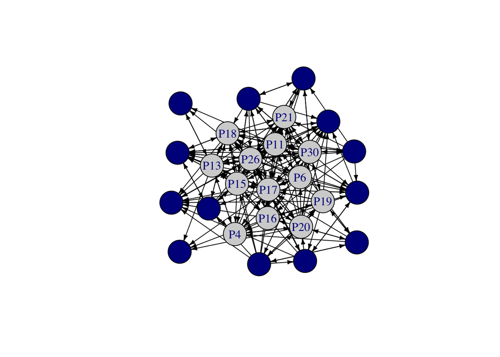

```r
# create a color column based on above median brokerage
df$broker_col <- "lightgray"
df$broker_col[which(df$brokerage > median(df$brokerage))] <- "darkblue"


set.seed(10) # for reproduction
layout1 <- layout_with_graphopt(Knet, niter=800, charge=0.2) # set up the layout

plot(Knet, layout=layout1,
     vertex.color=df$broker_col, edge.color="black",
     vertex.size=25, edge.arrow.size=0.4)
```

How do degree, brokerage and local clustering correlate? What does it mean? What is the general reason behind it (from a network structure point of view)?

```r
# simple correlations
cor(df$degree, df$brokerage)
```

```
## [1] -0.730879
```

```r
cor(df$degree, df$lc)
```

```
## [1] -0.6892955
```

```r
cor(df$brokerage, df$lc)
```

```
## [1] 0.5328967
```

# 4 **TASK 1**

1. create a plot where nodes with above average betweenness are marked by red.
2. How do brokerage and betweenness of nodes correlate?  
   Suggested steps:
1. use igraph’s betweenness function on Knet and assign results to df
2. create a column to df with colors based on above average betweenness
3. use the script above to plot the graph
4. measure a simple correlation in df

# 5 **Create random graphs**

There are many possibilities to create random graphs.  
Random graphs according to the **Erdos-Renyi model** (see lectures)  
*n* - number of nodes  
*p* - edge probability

```r
set.seed(10) # run together with the function for reproduction
ernet <- erdos.renyi.game(n = 100, p.or.m = 350, type = 'gnm')
ernet
```

```
## IGRAPH ea0bf6d U--- 100 350 -- Erdos renyi (gnm) graph
## + attr: name (g/c), type (g/c), loops (g/l), m (g/n)
## + edges from ea0bf6d:
##  [1]  4-- 5  5-- 8  1--10  5--10 10--13  3--15  6--16  8--17 14--17  9--18
## [11] 15--18  5--19 17--20  4--21 18--21  9--22  7--24 22--24 11--25 13--25
## [21] 15--25 21--25  1--26 15--26  2--27  6--27  8--27  2--28  5--28 19--28
## [31] 27--28  6--30 28--30 12--31 15--31 21--31 30--31 18--32  7--33  1--35
## [41] 21--35 11--36 32--37  2--38 33--38 34--38 17--39 26--39 10--40 16--40
## [51] 27--40 37--40 10--41 18--41 26--42 11--43 20--43 32--43 34--43 37--43
## [61]  3--44 14--44  4--45 23--45 13--46 19--46 25--46 34--46 33--47 38--47
## [71] 11--48 31--48 32--48 43--48 16--49 21--49 42--49 47--50 16--51 39--51
## + ... omitted several edges
```

Plot degree distribution

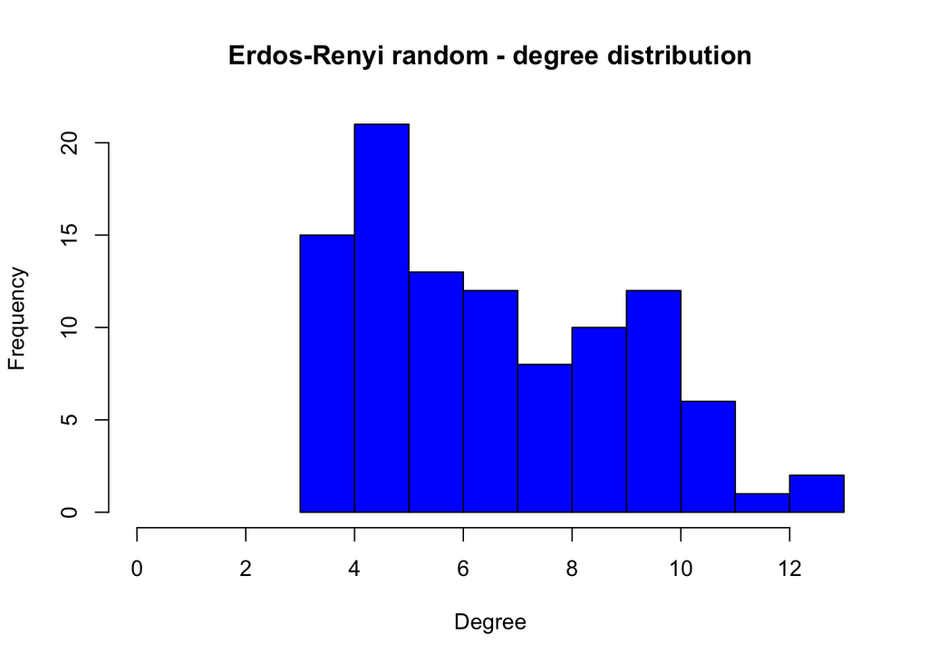

```r
hist(degree(ernet), main='Erdos-Renyi random - degree distribution',
     col='blue', xlab='Degree',
     xlim=c(0, max(degree(ernet))))
```

Scale-free networks according to the **Barabási-Albert model** (see lectures)  
*n* - number of nodes  
*power* - power of the preferential attachment

```r
set.seed(10)
banet <- barabasi.game(n = 100, p = 0.15)
banet
```

```
## IGRAPH 0904b56 D--- 100 99 -- Barabasi graph
## + attr: name (g/c), power (g/n), m (g/n), zero.appeal (g/n),
## | algorithm (g/c)
## + edges from 0904b56:
##  [1]  2-> 1  3-> 1  4-> 1  5-> 2  6-> 3  7-> 1  8-> 2  9-> 2 10-> 2 11-> 5
## [11] 12-> 4 13-> 6 14-> 6 15-> 2 16-> 7 17-> 4 18-> 5 19-> 1 20-> 4 21-> 6
## [21] 22->17 23->18 24->13 25->18 26-> 6 27-> 8 28->17 29->22 30-> 5 31->22
## [31] 32-> 8 33->15 34-> 2 35-> 4 36->31 37->13 38->25 39->30 40->37 41->25
## [41] 42->18 43-> 8 44-> 7 45-> 1 46->30 47-> 8 48-> 5 49-> 1 50->20 51-> 4
## [51] 52->37 53->15 54->49 55-> 9 56->21 57-> 7 58->28 59->21 60->22 61->19
## [61] 62->25 63-> 2 64-> 5 65->23 66->20 67->51 68->47 69->31 70->24 71-> 4
## + ... omitted several edges
```

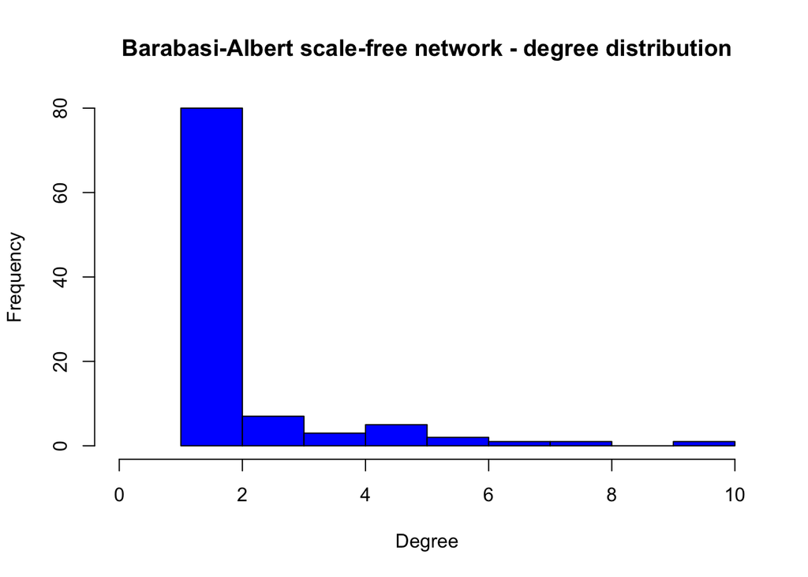

```r
hist(degree(banet), main='Barabasi-Albert scale-free network - degree distribution',
     col='blue', xlab='Degree',
     xlim=c(0, max(degree(banet))))
```

Generate random networks by the **Watts-Strogatz small-world model** (see lecture)  
*dim* - dimension of the starting set  
*size* - number of nodes  
*nei* - number of neighbors a node should be connected  
*p* - rewiring probability

```r
set.seed(10)
wsnet <- sample_smallworld(dim = 1, size = 100, nei = 3, p = 0.1)
wsnet
```

```
## IGRAPH 37c72b3 U--- 100 300 -- Watts-Strogatz random graph
## + attr: name (g/c), dim (g/n), size (g/n), nei (g/n), p (g/n),
## | loops (g/l), multiple (g/l)
## + edges from 37c72b3:
##  [1]  2--24  2-- 3  3-- 4  4-- 5  5-- 6  6-- 7  7-- 8  8-- 9  9--10 10--11
## [11] 11--12 12--13 13--14 14--15 15--16 17--34 17--18 18--19 19--20 20--21
## [21] 21--22 22--23 23--24 24--25 25--26 27--76 27--28 29--74 29--30 30--31
## [31] 31--32 32--33 33--34 34--35 35--36 36--37 37--38 38--39 39--40 40--41
## [41] 41--42 42--43 43--44 44--45 40--45 46--47 47--48 48--49 49--50 50--51
## [51] 51--52 52--96 53--54 54--55 55--56 56--57 58--67 58--59 59--60 27--61
## [61] 61--62 41--63 63--83 64--65 65--66 66--67 67--68 68--69 69--70 19--70
## + ... omitted several edges
```

Two basic properties of small-world networks are high clustering and low average path length.

```r
# clustering
transitivity(wsnet, type='global')
```

```
## [1] 0.3226633
```

```r
# average path length
mean_distance(wsnet)
```

```
## [1] 3.169091
```

# 6 **TASK 2**

1. Take the previously used Knet cluster network and simulate a random network with similar properties.
2. Compare clustering and path length in Knet and in the simulated random graph.  
   Suggested steps:
1. simulate an Erdos-Renyi random graph with the same amount of nodes and edges as in Knet  
   vcount() and ecount() give you the number of nodes and number of edges in a graph.
2. .. generate the random graph and check node and edge counts.
3. use the previously used functions to check clustering and average path length

# 7 **Dynamic network (intro)**

Networks (mostly) change over time! *’filmdata9806.csv* contains anonymized data on Hungarian feature films, their year of production and their creators. Let’s construct networks of movie creators and see how the network changes over time!

First, check the data!

```r
# import the dataset
film_df <- data.frame(read.csv("filmdata9806.csv", sep = ";", header = TRUE))
head(film_df)
```

|  | film_id | year | creator_id |
| --- | --- | --- | --- |
| 1 | 1332 | 1998 | 11065 |
| 2 | 1332 | 1998 | 11220 |
| 3 | 1332 | 1998 | 11585 |
| 4 | 1332 | 1998 | 11699 |
| 5 | 1332 | 1998 | 11753 |
| 6 | 1332 | 1998 | 12051 |

```r
# number of movies
length(unique(film_df$film_id))
```

```
## [1] 198
```

```r
# number of movie creators
length(unique(film_df$creator_id))
```

```
## [1] 608
```

```r
# years
table(film_df$year)
```

```
##
## 1998 1999 2000 2001 2002 2003 2004 2005 2006
##  114  148  155  103  168   57   97  110  162
```

To warm up, let’s construct a network only for 1998

```r
# filter data for 1998 only
data1998 <- subset(film_df, year==1998)

# table from the list
mat <- table(data1998$creator_id, data1998$film_id)

# create an n x n matrix = adjacency matrix
matrix <- mat %*% t(mat)

# set the diagonal to 0
diag(matrix) <- 0

# check the first 10x10 matrix (it is BIG!)
matrix[1:10, 1:10]
```

```
##
##         11013 11029 11048 11062 11065 11073 11075 11082 11105 11143
##   11013     0     0     0     0     0     0     0     0     0     0
##   11029     0     0     0     0     0     0     0     0     0     0
##   11048     0     0     0     0     0     0     0     0     0     0
##   11062     0     0     0     0     0     0     0     0     0     0
##   11065     0     0     0     0     0     0     0     0     0     0
##   11073     0     0     0     0     0     0     0     0     0     0
##   11075     0     0     0     0     0     0     0     0     0     0
##   11082     0     0     0     0     0     0     0     0     1     0
##   11105     0     0     0     0     0     0     0     1     0     0
##   11143     0     0     0     0     0     0     0     0     0     0
```

```r
# create a graph object
graph1998 <- graph.adjacency(matrix, mode='undirected')

# check the graph object
graph1998
```

```
## IGRAPH dc6e8ef UN-- 108 448 --
## + attr: name (v/c)
## + edges from dc6e8ef (vertex names):
##  [1] 11013--11458 11013--11485 11013--11508 11013--11636 11013--11695
##  [6] 11013--11840 11013--12158 11029--11343 11029--11645 11029--11933
## [11] 11029--12007 11048--11372 11048--11793 11048--11837 11048--11893
## [16] 11048--11949 11048--11950 11048--11953 11048--11958 11048--11964
## [21] 11048--11966 11048--11968 11048--11972 11048--11980 11048--11991
## [26] 11048--11995 11048--11998 11048--12049 11048--12102 11062--11246
## [31] 11062--11352 11062--11821 11065--11220 11065--11585 11065--11699
## [36] 11065--11753 11065--12051 11073--11180 11073--11452 11073--11782
## + ... omitted several edges
```

GREAT! But we need one for every year.. Write a loop that constructs a network for each year.

```r
graphs <- list() # store graphs in a list
years <- c(1998:2006) # iterator

for(i in 1:length(years)){
  dt <- subset(film_df, year==years[i]) # filter data by time
  mat <- table(dt$creator_id, dt$film_id)
  mat <- mat %*% t(mat)
  diag(mat) <- 0
  graphs[[i]] <- graph.adjacency(mat, mode='undirected')
}

# add names to list elements
names(graphs) <- paste0("graph", c(1998:2006))
```

How the number of nodes and edges changed over time?

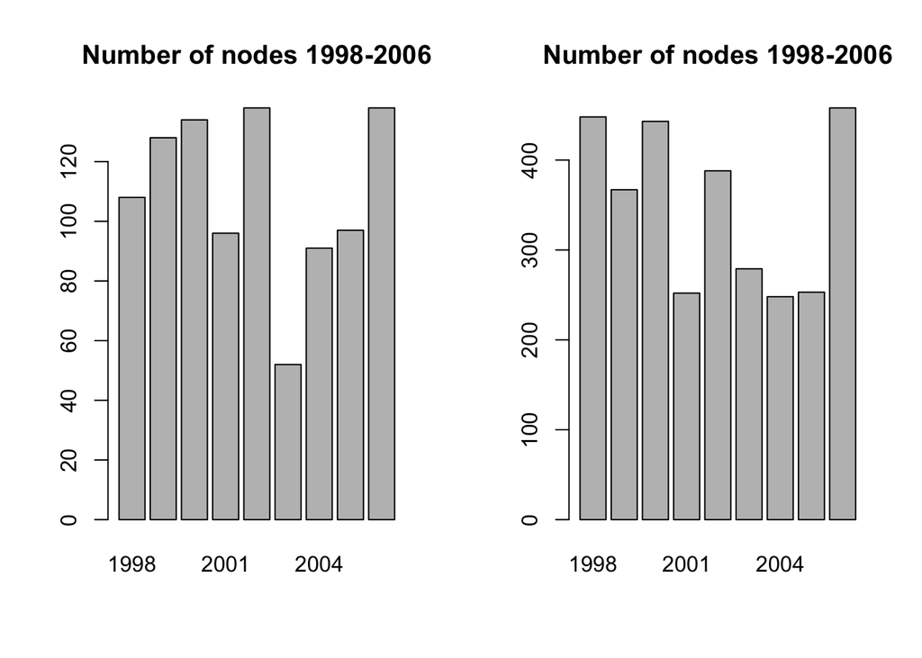

```r
# loop to collect data on nodes and edges
nodes <- c() # vector to store no. nodes
edges <- c() # vector to store no. edges
years <- c(1998:2006) # iterator

for(i in 1:length(years)){
  nodes[i] <- vcount(graphs[[i]])
  edges[i] <- ecount(graphs[[i]])
}

# dataframe
networks_df <- data.frame(years, nodes, edges)

# set up barplots
par(mfrow=c(1,2)) # 2 barplots next to each other

barplot(networks_df$nodes, names.arg = years, main="Number of nodes 1998-2006")
barplot(networks_df$edges, names.arg = years, main="Number of nodes 1998-2006")
```

Woah - there was a huge drop in the number of movie creators around 2003! Are these actually well-connected graphs?

```r
# check the number of components of the first network
components(graphs$graph2003)
```

```
## $membership
## 11020 11025 11154 11160 11208 11245 11248 11273 11286 11297 11301 11326
##     1     2     3     4     4     2     2     4     2     4     2     3
## 11339 11344 11351 11356 11367 11368 11379 11397 11404 11422 11457 11472
##     2     2     2     5     2     4     2     2     4     5     2     4
## 11475 11487 11493 11511 11542 11574 11613 11658 11663 11669 11751 11755
##     2     2     2     2     2     1     3     2     5     4     2     2
## 11770 11805 11840 11844 11854 11856 11880 11884 11892 12038 12041 12049
##     4     1     3     2     4     5     4     2     2     2     2     2
## 12063 12118 12150 12163
##     2     1     4     4
##
## $csize
## [1]  4 27  4 13  4
##
## $no
## [1] 5
```

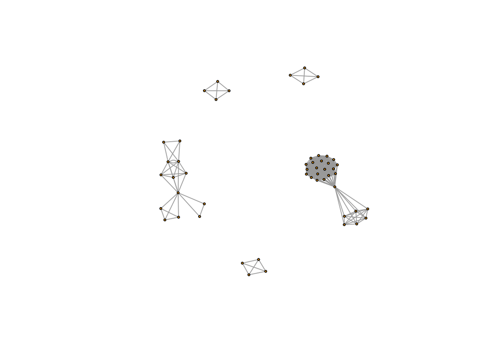

```r
# plot for visual check
plot(graphs$graph2003, vertex.size=2, vertex.label="")
```

Well - they are clearly NOT well connected. In 2003 the largest component consist of 27 nodes ONLY.  
TRICK - add a time dimension/decay to ties. Let’s assume that creators are connected for 3 years after collaborating on a movie.  
Let’s reconstruct networks this way and see how they changed!

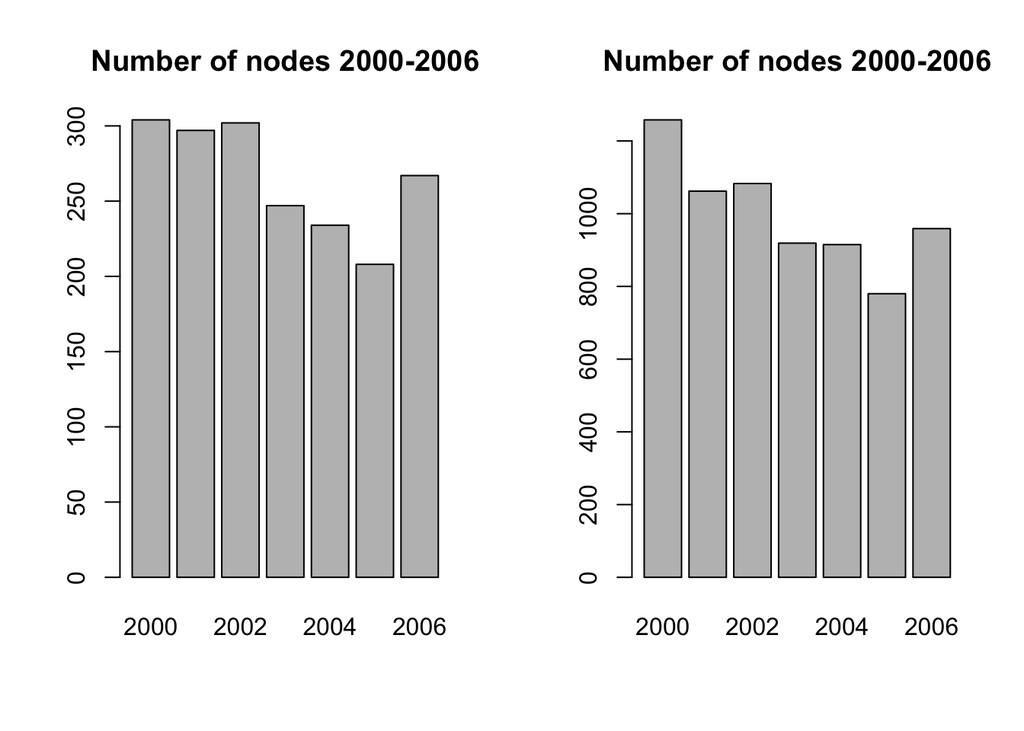

```r
graphs <- list() # store graphs in a list
years <- c(2000:2006) # iterator

for(i in 1:length(years)){
  dt <- subset(film_df, year>=(years[i]-2) & year<=years[i])
  mat <- table(dt$creator_id, dt$film_id)
  mat <- mat %*% t(mat)
  diag(mat) <- 0
  graphs[[i]] <- graph.adjacency(mat, mode='undirected')
}

# add names to list elements
names(graphs) <- paste0("graph", c(2000:2006))


# loop to collect data on nodes and edges
nodes <- c()
edges <- c()

for(i in 1:length(years)){
  nodes[i] <- vcount(graphs[[i]])
  edges[i] <- ecount(graphs[[i]])
}

networks_df <- data.frame(years, nodes, edges)

# set up barplots
par(mfrow=c(1,2)) # 2 barplots next to each other

barplot(networks_df$nodes, names.arg = years, main="Number of nodes 2000-2006")
barplot(networks_df$edges, names.arg = years, main="Number of nodes 2000-2006")
```

Check graph2003 again! How did it change?

```r
# components of graph2003
components(graphs$graph2003)
```

```
## $membership
## 11006 11009 11010 11011 11012 11020 11022 11025 11042 11044 11047 11048
##     1     1     1     1     2     1     1     1     1     3     1     1
## 11049 11054 11062 11063 11065 11066 11068 11071 11079 11080 11081 11084
##     1     1     4     1     1     1     1     1     1     1     1     5
## 11086 11095 11102 11107 11112 11113 11115 11140 11143 11145 11148 11154
##     1     1     1     1     1     1     1     1     1     1     4     1
## 11159 11160 11168 11171 11173 11174 11176 11188 11193 11194 11198 11201
##     1     1     6     1     1     1     1     3     1     1     7     1
## 11202 11206 11207 11208 11220 11221 11224 11225 11245 11248 11253 11259
##     3     1     1     1     1     1     1     1     1     1     1     8
## 11269 11273 11276 11277 11286 11292 11297 11301 11307 11309 11313 11322
##     1     1     1     1     1     5     1     1     1     1     1     1
## 11326 11328 11330 11332 11339 11344 11345 11348 11349 11351 11352 11354
##     1     9     1     4     1     1     1     1     7     1     4     1
```

[output cut: 34 more lines]

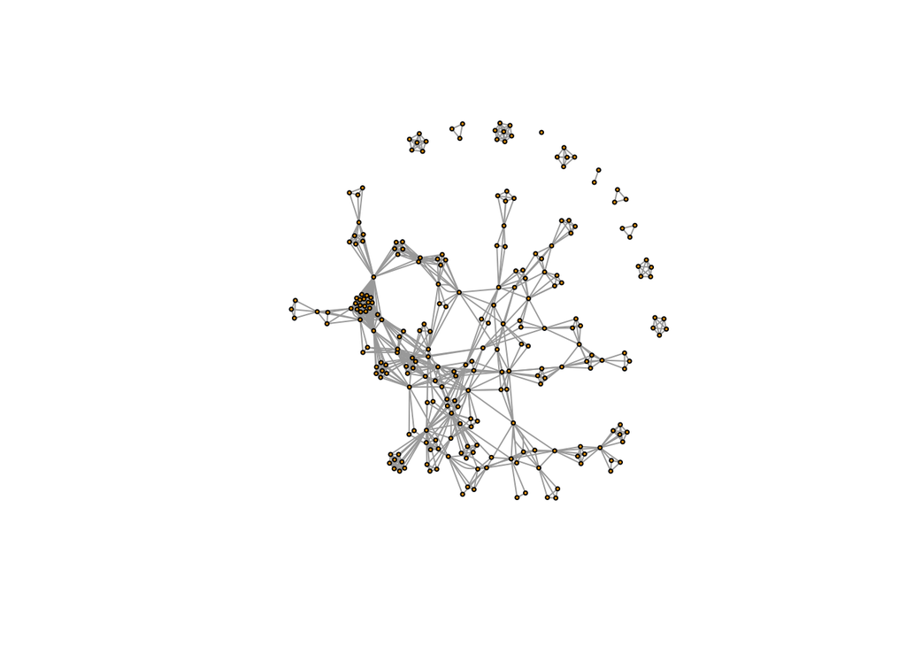

```r
# visual representation
plot(graphs$graph2003, vertex.size=2, vertex.label="")
```

# 8 **TASK 3**

Construct networks where ties represent collaborations on movies in the past 5 years. Plot the change of global clustering and average path length in these networks.  
Suggested steps:  
1. use the loop by which we constructed networks based on 3 year moving windows  
2. write a loop that measures mean_distance() and transitivity() on each network  
3. plot - and enjoy!

# 9 **Useful references**